# Nearest Neighbors

Author

Simone Brazzi

# 1 Theory

Super simple yet so effective! **Lazy models** and no parametrical. There are no assumptions about the data distribution. It overfits without learning from data, but memorizing it.

**Proximity search**: get a predefined number of the **nearest** observations to a poin and guess the label. It is also called the post-office problem: find the nearest post office.

## 1.1 KNN or K-Nearest Neighbors

Most popular and most used one. The predicted class is the one with the k observations nearest. **k** is an hyperparameter:

- For higher k, less noise.
- For lower k, clean decision boundaries.

Process:

- Choose k.
- Choose a metric -> euclidean distance.
- Search the k nearest to the observations we want to classify.
- Assign the class with higher frequency in the nearest neighbors.
- If there are multiple classes with the same frequency, it is assigned the class with the smallest total distance.

### 1.1.1 PROs

- Simple.
- Flexible for new data.
- Being not parametric, can deal with irregular decision boundaries.

### 1.1.2 CONs

- Computational load for big datasets.
- Outlier sensibility.
- Interpretability.

## 1.2 Distance metrics

### 1.2.2 Manhattan distance

$x_1 - x_2 + y_1 - y_2 $

The absolute value smooth big differences in the 2 dimensions, which are equally relevant

### 1.2.3 Minkowski

$(\mid x_1 - x_2 \mid^p + \mid x_1 - x_2 \mid^p)^{\frac{1}{p}}$

**p** lets control the weight to the greater differences. It is a general form of the Euclidean distance.

If p = 1 it is the Manhattan distance. If p = 2 it is an Euclidean distance.

## 1.3 RNN Radius Nearest Neighbors

It is used when the observations are **non uniformally** distributed. It focuses on a **radius R** instead of the number of observation. The predicted class is the one with the most observations in the radius R.

**R** is an hyperparameter with same characteristcs as k.

## 1.4 KNN vs RNN

- RNN is noise robust.
- With a good K, KNN is more accurate.

# 2 Practice

```python
import pandas as pd
import numpy as np
import matplotlib.pyplot as plt
from sklearn.preprocessing import MinMaxScaler
from sklearn.model_selection import train_test_split
from sklearn.metrics import log_loss, accuracy_score
from sklearn.datasets import make_classification

random_seed = 0
```

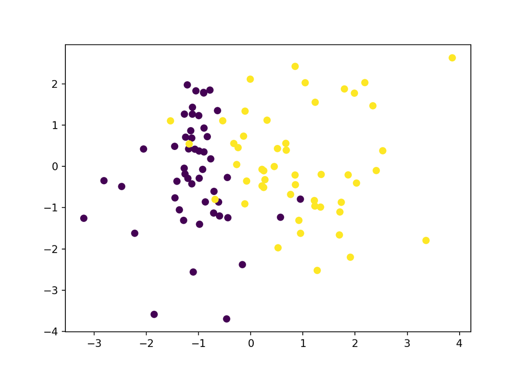

```python
x, y = make_classification(
  n_samples=100,
  n_features=2,
  n_informative=2,
  n_redundant=0,
  n_repeated=0,
  n_classes=2,
  random_state=random_seed
)

plt.close()
plt.scatter(x[:, 0], x[:, 1], c=y)
plt.show()
```

```python
xtrain, xtest, ytrain, ytest = train_test_split(
  x,
  y,
  test_size=.3,
  random_state=random_seed
)
```

## 2.1 KNN

```python
from sklearn.neighbors import KNeighborsClassifier
```

```python
Ks = [1, 2, 3, 4, 5, 10, 12, 15, 20, 30, 40, 50]

for k in Ks:

  print(f"k:{k}")
  knn = KNeighborsClassifier(
    n_neighbors=k
    )
  knn.fit(xtrain, ytrain)
  ypred_train = knn.predict(xtrain)
  yproba_train = knn.predict_proba(xtrain)
  ypred_test = knn.predict(xtest)
  yproba_test = knn.predict_proba(xtest)

  accuracy_train = accuracy_score(ytrain, ypred_train)
  accuracy_test = accuracy_score(ytest, ypred_test)

  log_loss_train = log_loss(ytrain, yproba_train)
  log_loss_test = log_loss(ytest, yproba_test)

  print(f"ACCURACY: TRAIN:{accuracy_train:.3f} TEST:{accuracy_test:.3f}")
  print(f"LOG LOSS: TRAIN{log_loss_train:.3f} TEST{log_loss_test:.3f}")
  print("\n")
```

[output not shown]

```python
knn = KNeighborsClassifier(
    n_neighbors=10
    )
knn.fit(xtrain, ytrain)
```

```
KNeighborsClassifier(n_neighbors=10)
```

```python
x0 = [0, 0]
ypred = knn.predict([x0])
ypred
```

```
array([1])
```

For the poin (0, 0), for this model it is yellow class.

Let see the neighbors.

```python
knn.kneighbors([x0])
```

```
(array([[0.22806125, 0.27128807, 0.36304814, 0.42146474, 0.45140126,
        0.51596759, 0.51944271, 0.52152733, 0.56700546, 0.64361102]]), array([[ 0, 66, 58,  5, 54,  4, 20, 68, 15, 64]]))
```

These are 2 `np.array`: one is the distance, the other the index of the neighbors in xtrain.

```python
distance, neighbors = knn.kneighbors([x0])

neighbors[0]
```

```
array([ 0, 66, 58,  5, 54,  4, 20, 68, 15, 64])
```

```python
x_neighbors = xtrain[neighbors[0]]
x_neighbors
```

```
array([[ 0.21654345, -0.07156026],
       [ 0.25020227, -0.10486202],
       [-0.07818714, -0.35452887],
       [ 0.27299061, -0.32110537],
       [ 0.45139447, -0.00247553],
       [-0.2415271 ,  0.4559465 ],
       [ 0.21726178, -0.47182417],
       [-0.44736931, -0.26805121],
       [ 0.24820673, -0.50979271],
       [-0.32372692,  0.55626974]])
```

These are the (x, y) coordinates for each neighbors.

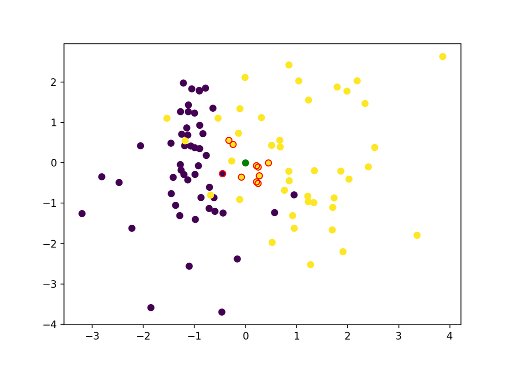

```python
plt.close()
plt.scatter(x[:, 0], x[:, 1], c=y)
plt.scatter(x0[0], x0[1], c="green")
plt.scatter(x_neighbors[:, 0], x_neighbors[:, 1], facecolor="none", edgecolor="red")
plt.show()
```

The red circled ones are the neighbors of the green observation.

```python
knn.predict_proba([x0])
```

```
array([[0.1, 0.9]])
```

9 out of 10 are yellow class, 1 out of 10 is of the purple one.

## 2.2 RNN

Using the RNN requires to normalize the data, because the features are used on a common scale.

```python
mms = MinMaxScaler()
xtrain = mms.fit_transform(xtrain)
xtest = mms.transform(xtest)
xtrain.min(), xtest.min()
```

```
(np.float64(0.0), np.float64(-0.05789998297467719))
```

```python
from sklearn.neighbors import RadiusNeighborsClassifier

Rs = [.2, .3, .4, .5, .6, .7, .8, .9, 1]

for r in Rs:

  print(f"r:{r}")
  rnn = RadiusNeighborsClassifier(
    radius=r
    )
  rnn.fit(xtrain, ytrain)
  ypred_train = rnn.predict(xtrain)
  yproba_train = rnn.predict_proba(xtrain)
  ypred_test = rnn.predict(xtest)
  yproba_test = rnn.predict_proba(xtest)

  accuracy_train = accuracy_score(ytrain, ypred_train)
  accuracy_test = accuracy_score(ytest, ypred_test)

  log_loss_train = log_loss(ytrain, yproba_train)
  log_loss_test = log_loss(ytest, yproba_test)

  print(f"ACCURACY: TRAIN:{accuracy_train:.3f} TEST:{accuracy_test:.3f}")
  print(f"LOG LOSS: TRAIN{log_loss_train:.3f} TEST{log_loss_test:.3f}")
  print("\n")
```

[output not shown]

```python
r = .2
rnn = RadiusNeighborsClassifier(radius=r)
rnn.fit(xtrain, ytrain)
```

```
RadiusNeighborsClassifier(radius=0.2)
```

```python
ypred = rnn.predict([x0])
ypred
```

```
array([0])
```

Doing so, the model return the same observation to the purple class! Lets plot the radius.

We are going to use the xtrain and ytrain, which are normalized, so we can plot the circle in the proper scale.

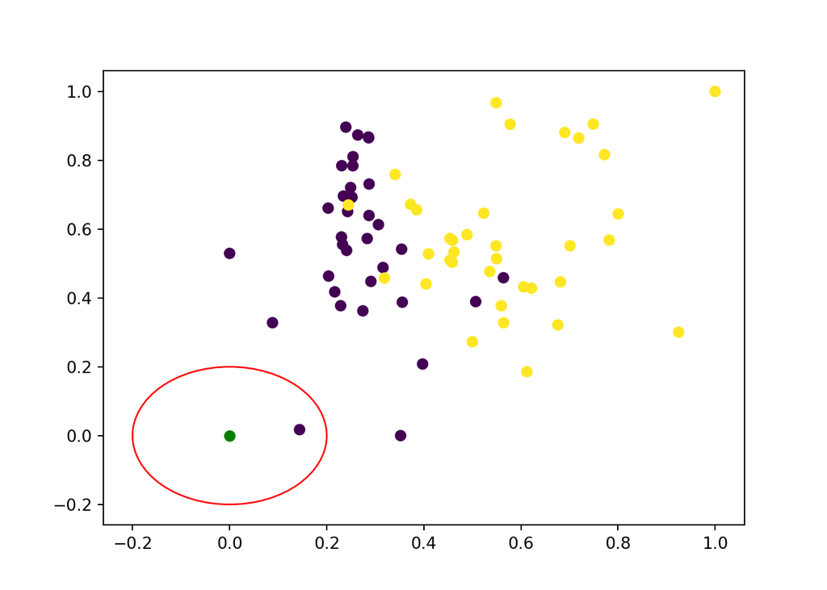

```python
plt.close()
fig, ax = plt.subplots()

ax.scatter(xtrain[:, 0], xtrain[:, 1], c=ytrain)
ax.scatter(x0[0], x0[1], c="green")

circle = plt.Circle((x0[0], x0[1]), r, color="r", fill=None)
ax.add_patch(circle)

plt.show()
```

```python
rnn.predict_proba([x0])
```

```
array([[1., 0.]])
```

The model is 100% sure the class is purple.

**Warning**

There is an error! x0 should be normalized!!! Lets do it!

Transform return an array of observations, while transform a bidimensional array.

```python
x_mms = mms.transform([x0])
ypred = rnn.predict(x_mms)
ypred
```

```
array([1])
```

```python
x_mms.shape
```

```
(1, 2)
```

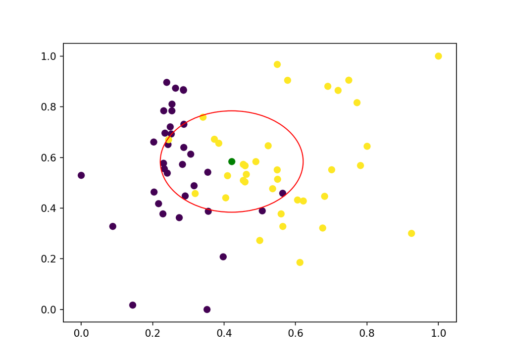

```python
plt.close()
fig, ax = plt.subplots()

ax.scatter(xtrain[:, 0], xtrain[:, 1], c=ytrain)
ax.scatter(x_mms[:, 0], x_mms[:, 1], c="green")

circle = plt.Circle((x_mms[:, 0], x_mms[:, 1]), r, color="r", fill=None)
ax.add_patch(circle)

plt.show()
```

```python
rnn.predict_proba(x_mms)
```

```
array([[0.4137931, 0.5862069]])
```

# 3 Exercise

Face Recognition model using Olivetti Faces Dataset.

## 3.1 Dataset

```python
from sklearn.datasets import fetch_olivetti_faces
```

```python
df = fetch_olivetti_faces()
x = df.images
y = df.target
```

From de description: “There are ten different images of each of 40 distinct subjects. For some subjects, the images were taken at different times, varying the lighting, facial expressions (open/closed eyes, smiling/not smiling) and facial details (glasses / no glasses). All the images were taken against a dark homogeneous background with the subjects in an upright, frontal position (with tolerance for some side movement). The image is quantized to 256 grey levels and stored as unsigned 8-bit integers; the loader will convert these to floating point values on the interval [0, 1], which are easier to work with for many algorithms. The”target” for this database is an integer from 0 to 39 indicating the identity of the person pictured; however, with only 10 examples per class, this relatively small dataset is more interesting from an unsupervised or semi-supervised perspective.

Little check if the features are normalized.

```python
x.min()
```

```
np.float32(0.0)
```

```python
x.max()
```

```
np.float32(1.0)
```

```python
df.data.shape
```

```
(400, 4096)
```

```python
x.shape
```

```
(400, 64, 64)
```

```python
y.shape
```

```
(400,)
```

```python
64 * 64
```

```
4096
```

```python
np.unique(y, return_counts=True)
```

```
(array([ 0,  1,  2,  3,  4,  5,  6,  7,  8,  9, 10, 11, 12, 13, 14, 15, 16,
       17, 18, 19, 20, 21, 22, 23, 24, 25, 26, 27, 28, 29, 30, 31, 32, 33,
       34, 35, 36, 37, 38, 39]), array([10, 10, 10, 10, 10, 10, 10, 10, 10, 10, 10, 10, 10, 10, 10, 10, 10,
       10, 10, 10, 10, 10, 10, 10, 10, 10, 10, 10, 10, 10, 10, 10, 10, 10,
       10, 10, 10, 10, 10, 10]))
```

```python
x[0].shape
```

```
(64, 64)
```

## 3.2 Plot

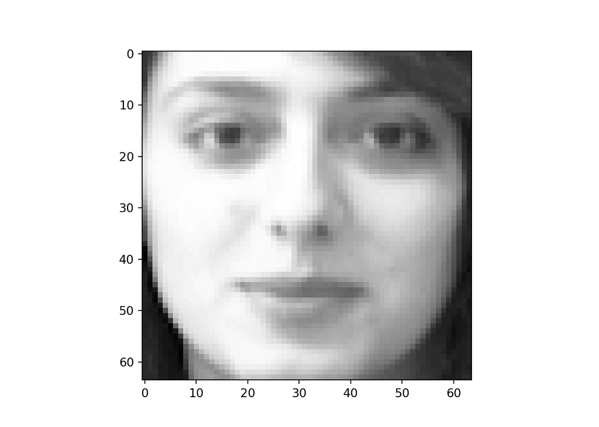

```python
plt.close()
plt.imshow(x[71], cmap="gray")
plt.show()
```

## 3.3 Model

```python
from sklearn.preprocessing import MinMaxScaler
from sklearn.neighbors import KNeighborsClassifier, RadiusNeighborsClassifier
from sklearn.model_selection import StratifiedKFold, GridSearchCV
from sklearn.metrics import classification_report
from sklearn.model_selection import train_test_split

x_flat = x.reshape(x.shape[0], -1)

xtrain, xtest, ytrain, ytest = train_test_split(
  x_flat,
  y,
  test_size=.3,
  random_state=42,
  stratify=y
)
# check if there are missing classes between ytrain and ytest
np.sum(1-np.isin(ytrain, ytest))
```

```
np.int64(0)
```

```python
mms = MinMaxScaler()
xtrain = mms.fit_transform(xtrain)
xtest = mms.transform(xtest)

param_grid = {
  "n_neighbors" : [1, 2, 3, 4, 5, 10, 12, 15, 20, 30, 40, 50]
}
knn = KNeighborsClassifier()
grid_search = GridSearchCV(
  knn,
  param_grid,
  cv=5,
  scoring="accuracy",
  n_jobs=-1
)

grid_search.fit(xtrain, ytrain)
```

```
GridSearchCV(cv=5, estimator=KNeighborsClassifier(), n_jobs=-1,
             param_grid={'n_neighbors': [1, 2, 3, 4, 5, 10, 12, 15, 20, 30, 40,
                                         50]},
             scoring='accuracy')
```

```python
print("Best parameters:", grid_search.best_params_)
```

```
Best parameters: {'n_neighbors': 1}
```

```python
print("Best cross-validation score:", grid_search.best_score_)
```

```
Best cross-validation score: 0.875
```

```python
# Use the best model to make predictions
best_knn = grid_search.best_estimator_
ypred_train = best_knn.predict(xtrain)
yproba_train = best_knn.predict_proba(xtrain)
ypred_test = best_knn.predict(xtest)
yproba_test = best_knn.predict_proba(xtest)

# Calculate and print metrics
accuracy_train = accuracy_score(ytrain, ypred_train)
accuracy_test = accuracy_score(ytest, ypred_test)
log_loss_train = log_loss(ytrain, yproba_train)
log_loss_test = log_loss(ytest, yproba_test)

print(f"K: {best_knn}")
```

```
K: KNeighborsClassifier(n_neighbors=1)
```

```python
print(f"ACCURACY: TRAIN:{accuracy_train:.3f} TEST:{accuracy_test:.3f}")
```

```
ACCURACY: TRAIN:1.000 TEST:0.933
```

```python
print(f"LOG LOSS: TRAIN:{log_loss_train:.3f} TEST:{log_loss_test:.3f}")
```

```
LOG LOSS: TRAIN:0.000 TEST:2.403
```

Considering it is clearly overfitting, we will use another k.

```python
results = grid_search.cv_results_
for mean_score, params in zip(results['mean_test_score'], results['params']):
    print(f"Mean test score: {mean_score:.3f} - Parameters: {params}")
```

```
Mean test score: 0.875 - Parameters: {'n_neighbors': 1}
Mean test score: 0.796 - Parameters: {'n_neighbors': 2}
Mean test score: 0.796 - Parameters: {'n_neighbors': 3}
Mean test score: 0.782 - Parameters: {'n_neighbors': 4}
Mean test score: 0.768 - Parameters: {'n_neighbors': 5}
Mean test score: 0.611 - Parameters: {'n_neighbors': 10}
Mean test score: 0.589 - Parameters: {'n_neighbors': 12}
Mean test score: 0.561 - Parameters: {'n_neighbors': 15}
Mean test score: 0.464 - Parameters: {'n_neighbors': 20}
Mean test score: 0.364 - Parameters: {'n_neighbors': 30}
Mean test score: 0.293 - Parameters: {'n_neighbors': 40}
Mean test score: 0.218 - Parameters: {'n_neighbors': 50}
```

```python
knn = KNeighborsClassifier(n_neighbors=3)
knn.fit(xtrain, ytrain)
```

```
KNeighborsClassifier(n_neighbors=3)
```

```python
knn.score(xtest, ytest)
```

```
0.8416666666666667
```

```python
ypred = knn.predict(xtest)
print(classification_report(ytest, ypred))
```

[output not shown]

[output cut: 37 more lines]